# Data Visualization

각 그래프의 특성을 알고 상황에 맞게 쓸 줄 알아야 한다

```python
%matplotlib inline
import pandas as pd
```

```python
df = pd.read_csv('broadcast.csv', index_col=0)
```

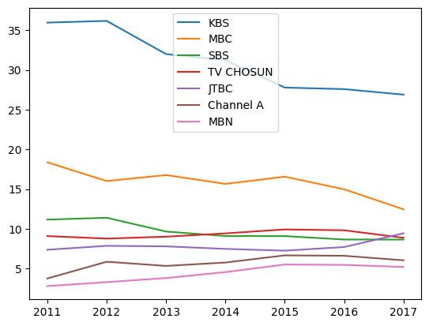

```python
df.plot()
#df.plot(kind='line') line이 기본값이다
```

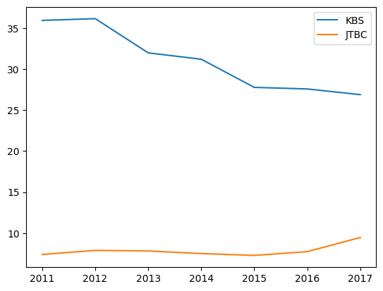

```python
df.plot(y=['KBS', 'JTBC'])
```

```python
df['KBS']
```

```
2011    35.951
2012    36.163
2013    31.989
2014    31.210
2015    27.777
2016    27.583
2017    26.890
Name: KBS, dtype: float64
```

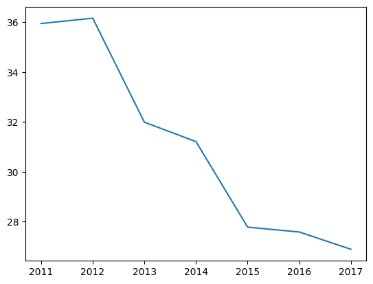

```python
df['KBS'].plot()
```

```python
df[['KBS', 'JTBC']]
```

|  | KBS | JTBC |
| --- | --- | --- |
| 2011 | 35.951 | 7.380 |
| 2012 | 36.163 | 7.878 |
| 2013 | 31.989 | 7.810 |
| 2014 | 31.210 | 7.490 |
| 2015 | 27.777 | 7.267 |
| 2016 | 27.583 | 7.727 |
| 2017 | 26.890 | 9.453 |

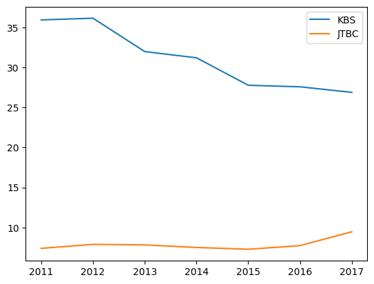

```python
df[['KBS', 'JTBC']].plot()
```

```python
gdp = pd.read_csv('gdp.csv', index_col=0)
gdp
```

|  | Aruba | Angola | Albania | Andorra | Arab World | United Arab Emirates | Argentina | Armenia | Antigua and Barbuda | Australia | ... | St. Vincent and the Grenadines | Vietnam | Vanuatu | World | Samoa | Kosovo | Yemen, Rep. | South Africa | Zambia | Zimbabwe |
| --- | --- | --- | --- | --- | --- | --- | --- | --- | --- | --- | --- | --- | --- | --- | --- | --- | --- | --- | --- | --- | --- |
| 2000 | 1.873453e+09 | 9.129595e+09 | 3.480355e+09 | 1.434430e+09 | 7.351881e+11 | 1.043374e+11 | 2.842038e+11 | 1.911564e+09 | 8.301588e+08 | 4.150342e+11 | ... | 3.962614e+08 | 3.117252e+10 | 2.720147e+08 | 3.359786e+13 | 2.690197e+08 | 1.849196e+09 | 9.652436e+09 | 1.363619e+11 | 3.600683e+09 | 6.689958e+09 |
| 2001 | 1.920112e+09 | 8.936064e+09 | 3.922101e+09 | 1.496913e+09 | 7.234491e+11 | 1.033116e+11 | 2.686968e+11 | 2.118468e+09 | 8.007403e+08 | 3.782151e+11 | ... | 4.300393e+08 | 3.268520e+10 | 2.579269e+08 | 3.340101e+13 | 2.730884e+08 | 2.535334e+09 | 9.861560e+09 | 1.216008e+11 | 4.094481e+09 | 6.777385e+09 |
| 2002 | 1.941341e+09 | 1.528559e+10 | 4.348068e+09 | 1.733117e+09 | 7.292314e+11 | 1.098162e+11 | 9.772400e+10 | 2.376335e+09 | 8.146153e+08 | 3.944867e+11 | ... | 4.618834e+08 | 3.506411e+10 | 2.626038e+08 | 3.468623e+13 | 2.880789e+08 | 2.406271e+09 | 1.069463e+10 | 1.157481e+11 | 4.193846e+09 | 6.342116e+09 |
| 2003 | 2.021229e+09 | 1.781271e+10 | 5.611496e+09 | 2.398646e+09 | 8.233413e+11 | 1.243464e+11 | 1.275870e+11 | 2.807061e+09 | 8.556431e+08 | 4.662947e+11 | ... | 4.818063e+08 | 3.955251e+10 | 3.144631e+08 | 3.892649e+13 | 3.388386e+08 | 2.790456e+09 | 1.177797e+10 | 1.752569e+11 | 4.901840e+09 | 5.727592e+09 |
| 2004 | 2.228492e+09 | 2.355205e+10 | 7.184686e+09 | 2.935659e+09 | 9.643273e+11 | 1.478244e+11 | 1.646579e+11 | 3.576615e+09 | 9.195771e+08 | 6.119043e+11 | ... | 5.219751e+08 | 4.542785e+10 | 3.649969e+08 | 4.384476e+13 | 4.203202e+08 | 3.556757e+09 | 1.387279e+10 | 2.289373e+11 | 6.221078e+09 | 5.805598e+09 |
| 2005 | 2.330726e+09 | 3.697092e+10 | 8.052074e+09 | 3.255789e+09 | 1.185143e+12 | 1.806170e+11 | 1.987371e+11 | 4.900470e+09 | 1.022191e+09 | 6.926417e+11 | ... | 5.507287e+08 | 5.763326e+10 | 3.949626e+08 | 4.748718e+13 | 4.626490e+08 | 3.663102e+09 | 1.674634e+10 | 2.576714e+11 | 8.331870e+09 | 5.755215e+09 |
| 2006 | 2.424581e+09 | 5.238101e+10 | 8.896073e+09 | 3.543257e+09 | 1.404653e+12 | 2.221165e+11 | 2.325573e+11 | 6.384452e+09 | 1.157005e+09 | 7.455219e+11 | ... | 6.109300e+08 | 6.637166e+10 | 4.393768e+08 | 5.144603e+13 | 5.085037e+08 | 3.846820e+09 | 1.906198e+10 | 2.716385e+11 | 1.275686e+10 | 5.443896e+09 |
| 2007 | 2.615084e+09 | 6.526645e+10 | 1.067732e+10 | 4.016972e+09 | 1.638214e+12 | 2.579161e+11 | 2.875305e+11 | 9.206302e+09 | 1.311401e+09 | 8.519628e+11 | ... | 6.844463e+08 | 7.741443e+10 | 5.264283e+08 | 5.795330e+13 | 5.509707e+08 | 4.655899e+09 | 2.165053e+10 | 2.994155e+11 | 1.405696e+10 | 5.291950e+09 |
| 2008 | 2.745251e+09 | 8.853861e+10 | 1.288135e+10 | 4.007353e+09 | 2.078570e+12 | 3.154746e+11 | 3.615580e+11 | 1.166204e+10 | 1.368431e+09 | 1.052585e+12 | ... | 6.954289e+08 | 9.913030e+10 | 6.079586e+08 | 6.357489e+13 | 6.441325e+08 | 5.687418e+09 | 2.691085e+10 | 2.867698e+11 | 1.791086e+10 | 4.415703e+09 |
| 2009 | 2.498883e+09 | 7.030716e+10 | 1.204421e+10 | 3.660531e+09 | 1.796200e+12 | 2.535474e+11 | 3.329765e+11 | 8.647937e+09 | 1.224253e+09 | 9.264482e+11 | ... | 6.749225e+08 | 1.060147e+11 | 6.100666e+08 | 6.026707e+13 | 5.609595e+08 | 5.653793e+09 | 2.513027e+10 | 2.959365e+11 | 1.532834e+10 | 9.665793e+09 |
| 2010 | 2.390503e+09 | 8.379950e+10 | 1.192696e+10 | 3.355695e+09 | 2.109932e+12 | 2.897873e+11 | 4.236274e+11 | 9.260285e+09 | 1.152469e+09 | 1.144261e+12 | ... | 6.812260e+08 | 1.159317e+11 | 7.008043e+08 | 6.596588e+13 | 6.430467e+08 | 5.830464e+09 | 3.090675e+10 | 3.753494e+11 | 2.026556e+10 | 1.204166e+10 |
| 2011 | 2.549721e+09 | 1.117897e+11 | 1.289087e+10 | 3.442063e+09 | 2.501739e+12 | 3.506660e+11 | 5.301633e+11 | 1.014211e+10 | 1.142043e+09 | 1.394281e+12 | ... | 6.761294e+08 | 1.355394e+11 | 7.921497e+08 | 7.331678e+13 | 7.397851e+08 | 6.691827e+09 | 3.272642e+10 | 4.164189e+11 | 2.346010e+10 | 1.410192e+10 |
| 2012 | 2.534637e+09 | 1.280529e+11 | 1.231978e+10 | 3.164615e+09 | 2.786787e+12 | 3.745906e+11 | 5.459824e+11 | 1.061932e+10 | 1.211412e+09 | 1.543411e+12 | ... | 6.929337e+08 | 1.558200e+11 | 7.817029e+08 | 7.499371e+13 | 8.011686e+08 | 6.499936e+09 | 3.540134e+10 | 3.963279e+11 | 2.550337e+10 | 1.711485e+10 |
| 2013 | 2.581564e+09 | 1.367099e+11 | 1.277628e+10 | 3.281585e+09 | 2.866861e+12 | 3.901076e+11 | 5.520251e+11 | 1.112147e+10 | 1.192920e+09 | 1.573697e+12 | ... | 7.212090e+08 | 1.712220e+11 | 8.017876e+08 | 7.709879e+13 | 8.048085e+08 | 7.071960e+09 | 4.041523e+10 | 3.666432e+11 | 2.804546e+10 | 1.909102e+10 |
| 2014 | 2.649721e+09 | 1.457122e+11 | 1.322825e+10 | 3.350736e+09 | 2.908394e+12 | 4.031371e+11 | 5.263197e+11 | 1.160951e+10 | 1.275577e+09 | 1.464955e+12 | ... | 7.277144e+08 | 1.862047e+11 | 8.149543e+08 | 7.918846e+13 | 8.051626e+08 | 7.386891e+09 | 4.322858e+10 | 3.506362e+11 | 2.715063e+10 | 1.949552e+10 |
| 2015 | 2.691620e+09 | 1.161936e+11 | 1.138693e+10 | 2.811489e+09 | 2.560754e+12 | 3.581351e+11 | 5.947493e+11 | 1.055334e+10 | 1.359195e+09 | 1.349034e+12 | ... | 7.554580e+08 | 1.932411e+11 | 7.379172e+08 | 7.491609e+13 | 8.041006e+08 | 6.440612e+09 | 4.559357e+10 | 3.175368e+11 | 2.115439e+10 | 1.996312e+10 |
| 2016 | 2.646927e+09 | 1.011239e+11 | 1.188368e+10 | 2.877312e+09 | 2.513936e+12 | 3.570451e+11 | 5.548609e+11 | 1.054614e+10 | 1.464630e+09 | 1.208039e+12 | ... | 7.707622e+08 | 2.052762e+11 | 7.879426e+08 | 7.599738e+13 | 7.866400e+08 | 6.714712e+09 | 3.643665e+10 | 2.957466e+11 | 2.095475e+10 | 2.054868e+10 |
| 2017 | 2.700559e+09 | 1.221238e+11 | 1.303854e+10 | 3.012914e+09 | 2.586311e+12 | 3.825751e+11 | 6.374303e+11 | 1.153659e+10 | 1.510085e+09 | 1.323421e+12 | ... | 7.852225e+08 | 2.237799e+11 | 8.628798e+08 | 8.073758e+13 | 8.409280e+08 | 7.244889e+09 | 3.126768e+10 | 3.488716e+11 | 2.586814e+10 | 2.204090e+10 |

18 rows × 232 columns

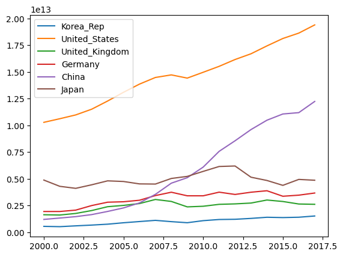

```python
gdp.plot(y = ['Korea_Rep', 'United_States', 'United_Kingdom', 'Germany', 'China', 'Japan'])
```

```python
sv = pd.read_csv('silicon_valley_summary.csv')
sv
```

|  | job_category | race_ethnicity | gender | count | percentage |
| --- | --- | --- | --- | --- | --- |
| 0 | All workers | White | Male | 268883 | 41.257252 |
| 1 | All workers | White | Female | 105560 | 16.197065 |
| 2 | All workers | Black_or_African American | Male | 17508 | 2.686417 |
| 3 | All workers | Black_or_African American | Female | 11479 | 1.761331 |
| 4 | All workers | Asian | Male | 125347 | 19.233171 |
| 5 | All workers | Asian | Female | 58049 | 8.907005 |
| 6 | All workers | Hispanic_or_Latino | Male | 32201 | 4.940903 |
| 7 | All workers | Hispanic_or_Latino | Female | 15512 | 2.380152 |
| 8 | All workers | All | Male | 454813 | 69.786244 |
| 9 | All workers | All | Female | 196910 | 30.213756 |
| 10 | All workers | Totals | Both | 651723 | 100.000000 |
| 11 | Executives | White | Male | 7282 | 58.678485 |
| 12 | Executives | White | Female | 1818 | 14.649476 |
| 13 | Executives | Black_or_African American | Male | 120 | 0.966962 |
| 14 | Executives | Black_or_African American | Female | 53 | 0.427075 |
| 15 | Executives | Asian | Male | 2023 | 16.301370 |
| 16 | Executives | Asian | Female | 556 | 4.500000 |
| 17 | Executives | Hispanic_or_Latino | Male | 266 | 2.143433 |
| 18 | Executives | Hispanic_or_Latino | Female | 103 | 0.829976 |
| 19 | Executives | All | Male | 9824 | 79.161966 |
| 20 | Executives | All | Female | 2586 | 20.838034 |
| 21 | Executives | Totals | Both | 12410 | 100.000000 |
| 22 | Managers | White | Male | 48311 | 46.479253 |
| 23 | Managers | White | Female | 18935 | 18.217065 |
| 24 | Managers | Black_or_African American | Male | 1575 | 1.515283 |
| 25 | Managers | Black_or_African American | Female | 978 | 0.940918 |
| 26 | Managers | Asian | Male | 18563 | 17.859170 |
| 27 | Managers | Asian | Female | 8084 | 7.777489 |
| 28 | Managers | Hispanic_or_Latino | Male | 3741 | 3.599157 |
| 29 | Managers | Hispanic_or_Latino | Female | 1642 | 1.579742 |
| 30 | Managers | All | Male | 73526 | 70.738207 |
| 31 | Managers | All | Female | 30415 | 29.261793 |
| 32 | Managers | Totals | Both | 103941 | 100.000000 |
| 33 | Professionals | White | Male | 133311 | 38.660592 |
| 34 | Professionals | White | Female | 47505 | 13.776593 |
| 35 | Professionals | Black_or_African American | Male | 6301 | 1.827309 |
| 36 | Professionals | Black_or_African American | Female | 3756 | 1.089251 |
| 37 | Professionals | Asian | Male | 89365 | 25.916120 |
| 38 | Professionals | Asian | Female | 39902 | 11.571700 |
| 39 | Professionals | Hispanic_or_Latino | Male | 11820 | 3.427836 |
| 40 | Professionals | Hispanic_or_Latino | Female | 5533 | 1.604587 |
| 41 | Professionals | All | Male | 245461 | 71.184430 |
| 42 | Professionals | All | Female | 99363 | 28.815570 |
| 43 | Professionals | Totals | Both | 344824 | 100.000000 |

아니 ... 답이 all이 없어서 뭔가 멋진 방법이 있나 했더니 나랑 똑같이 손으로 뺀 거잖아 ... ?

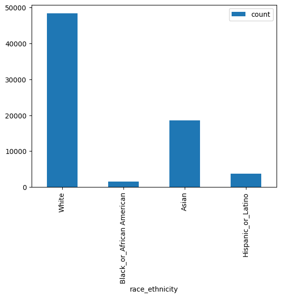

```python
man = sv['job_category'] == 'Managers'
male = sv['gender'] == 'Male'
nall = sv['race_ethnicity'] != 'All'
sv.loc[man & male & nall].plot(kind='bar', x = 'race_ethnicity', y = 'count')
```

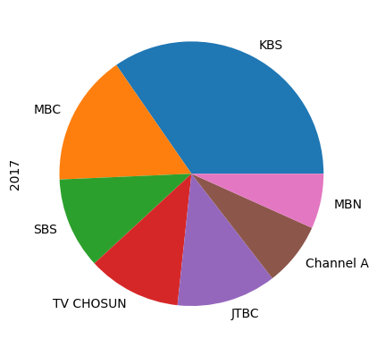

```python
df.loc[2017].plot(kind='pie')
```

```python
svd = pd.read_csv('silicon_valley_details.csv')
svd
```

|  | company | year | race | gender | job_category | count |
| --- | --- | --- | --- | --- | --- | --- |
| 0 | 23andMe | 2016 | Hispanic_or_Latino | male | Executives | 0 |
| 1 | 23andMe | 2016 | Hispanic_or_Latino | male | Managers | 1 |
| 2 | 23andMe | 2016 | Hispanic_or_Latino | male | Professionals | 7 |
| 3 | 23andMe | 2016 | Hispanic_or_Latino | male | Technicians | 0 |
| 4 | 23andMe | 2016 | Hispanic_or_Latino | male | Sales workers | 0 |
| ... | ... | ... | ... | ... | ... | ... |
| 4435 | Sanmina | 2016 | Overall_totals | NaN | laborers and helpers | 4 |
| 4436 | Sanmina | 2016 | Overall_totals | NaN | Service workers | 57 |
| 4437 | Sanmina | 2016 | Overall_totals | NaN | Totals | 5205 |
| 4438 | Sanmina | 2016 | Overall_totals | NaN | Previous_totals | 5615 |
| 4439 | Sanmina | 2016 | Overall_totals | NaN | Managers | 591 |

4440 rows × 6 columns

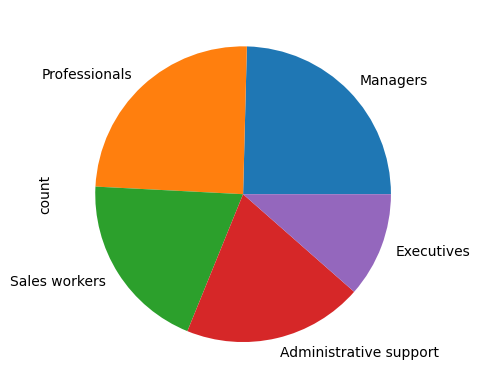

```python
adb = svd['company'] == 'Adobe'
ntotals = svd['job_category'] != 'Totals'
nsub = svd['job_category'] != 'Previous_totals'
nzero = svd['count'] > 0
cnt = svd.loc[adb & ntotals & nsub & nzero]['job_category'].value_counts()
cnt.plot(kind = 'pie')
```

하 진짜 파라미터로 어떤 걸 넣는지 같은 건 알려주고 문제를 풀라고 하든가  
이게 짱 답답한 부분인긴 한데 구글링하면서 스스로 답을 찾는 게 개발자 마인드고 다 떠먹여 주는 게 아니라 개발자 마인드를 길러야 한다는 사람도 있다  
죽빵이라도 갈겨야 한다

왜 빡쳤냐면 파이 그래프가 인덱스를 이름표로 붙인다는 걸 설명도 안 해놓고 그걸 안 맞추면 틀리게 해놨다

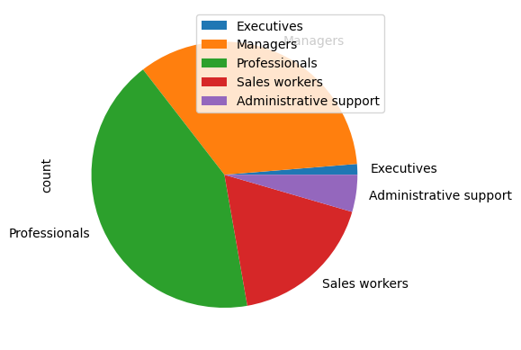

```python
nrace = svd['race'] == 'Overall_totals'
base = svd.loc[adb & nrace & nzero & ntotals & nsub]
base.set_index('job_category', inplace = True)
base.plot(kind = 'pie', y = 'count')
```

```python
stb = pd.read_csv('starbucks_drinks.csv')
stb
```

|  | Beverage_category | Beverage | Beverage_prep | Calories | Total Fat (g) | Trans Fat (g) | Saturated Fat (g) | Sodium (mg) | Total Carbohydrates (g) | Cholesterol (mg) | Dietary Fibre (g) | Sugars (g) | Protein (g) | Vitamin A (% DV) | Vitamin C (% DV) | Calcium (% DV) | Iron (% DV) | Caffeine (mg) |
| --- | --- | --- | --- | --- | --- | --- | --- | --- | --- | --- | --- | --- | --- | --- | --- | --- | --- | --- |
| 0 | Coffee | Brewed Coffee | Short | 3 | 0.1 | 0.0 | 0.0 | 0 | 5 | 0 | 0 | 0 | 0.3 | 0% | 0% | 0% | 0% | 175 |
| 1 | Coffee | Brewed Coffee | Tall | 4 | 0.1 | 0.0 | 0.0 | 0 | 10 | 0 | 0 | 0 | 0.5 | 0% | 0% | 0% | 0% | 260 |
| 2 | Coffee | Brewed Coffee | Grande | 5 | 0.1 | 0.0 | 0.0 | 0 | 10 | 0 | 0 | 0 | 1.0 | 0% | 0% | 0% | 0% | 330 |
| 3 | Coffee | Brewed Coffee | Venti | 5 | 0.1 | 0.0 | 0.0 | 0 | 10 | 0 | 0 | 0 | 1.0 | 0% | 0% | 2% | 0% | 410 |
| 4 | Classic Espresso Drinks | Caffè Latte | Short Nonfat Milk | 70 | 0.1 | 0.1 | 0.0 | 5 | 75 | 10 | 0 | 9 | 6.0 | 10% | 0% | 20% | 0% | 75 |
| ... | ... | ... | ... | ... | ... | ... | ... | ... | ... | ... | ... | ... | ... | ... | ... | ... | ... | ... |
| 214 | Frappuccino® Blended Crème | Strawberries & Crème (Without Whipped Cream) | Soymilk | 320 | 3 2 | 0.4 | 0.0 | 0 | 250 | 67 | 1 | 64 | 5.0 | 6% | 8% | 20% | 10% | 0 |
| 215 | Frappuccino® Blended Crème | Vanilla Bean (Without Whipped Cream) | Tall Nonfat Milk | 170 | 0.1 | 0.1 | 0.0 | 0 | 160 | 39 | 0 | 38 | 4.0 | 6% | 0% | 10% | 0% | 0 |
| 216 | Frappuccino® Blended Crème | Vanilla Bean (Without Whipped Cream) | Whole Milk | 200 | 3.5 | 2.0 | 0.1 | 10 | 160 | 39 | 0 | 38 | 3.0 | 6% | 0% | 10% | 0% | 0 |
| 217 | Frappuccino® Blended Crème | Vanilla Bean (Without Whipped Cream) | Soymilk | 180 | 1.5 | 0.2 | 0.0 | 0 | 160 | 37 | 1 | 35 | 3.0 | 4% | 0% | 10% | 6% | 0 |
| 218 | Frappuccino® Blended Crème | Vanilla Bean (Without Whipped Cream) | Grande Nonfat Milk | 240 | 0.1 | 0.1 | 0.0 | 5 | 230 | 56 | 0 | 55 | 5.0 | 8% | 0% | 15% | 0% | 0 |

219 rows × 18 columns

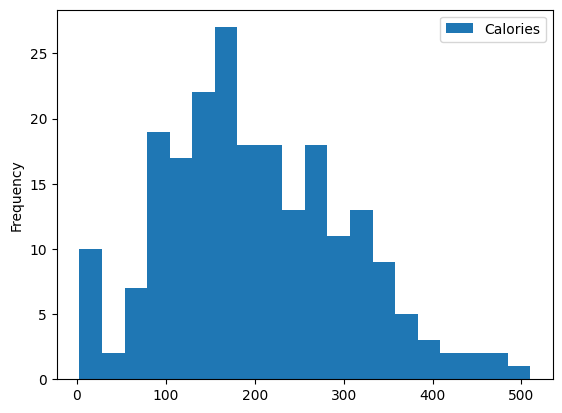

```python
stb.plot(kind='hist', y='Calories', bins = 20)
```

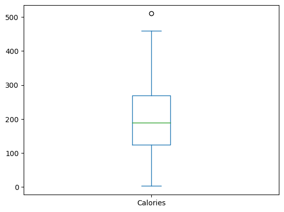

```python
stb.plot(kind='box', y='Calories')
```

```python
wd = pd.read_csv('world_indexes.csv')
wd
```

|  | Id | Human Development Index HDI-2014 | Gini coefficient 2005-2013 | Adolescent birth rate 15-19 per 100k 20102015 | Birth registration funder age 5 2005-2013 | Carbon dioxide emissionsAverage annual growth | Carbon dioxide emissions per capita 2011 Tones | Change forest percentable 1900 to 2012 | Change mobile usage 2009 2014 | Consumer price index 2013 | ... | Renewable sources percentage of total 2012 | Research and development expenditure 2005-2012 | Secondary 2008-2014 | Share of seats in parliament percentage held by womand 2014 | Stock of immigrants percentage of population 2013 | Taxes on income profit and capital gain 205 2013 | Tertiary -2008-2014 | Total tax revenue of GDP 2005-2013 | Tuberculosis rate per thousands 2012 | Under-five Mortality 2013 thousands |
| --- | --- | --- | --- | --- | --- | --- | --- | --- | --- | --- | --- | --- | --- | --- | --- | --- | --- | --- | --- | --- | --- |
| 0 | Norway | 0.943877 | 26.83 | 7.834 | 100.000000 | 0.778925 | 9.192879 | 11.914567 | 5.22 | 104.194175 | ... | 47.752676 | 1.654740 | 111.061300 | 39.644970 | 13.772622 | 31.798391 | 74.10112 | 27.288097 | 0.14 | 2.8 |
| 1 | Australia | 0.934958 | 34.01 | 12.059 | 100.000000 | 1.090351 | 16.519210 | -4.561812 | 30.27 | 107.789440 | ... | 4.632202 | 2.385620 | 135.535430 | 30.530974 | 27.711793 | 65.333748 | 86.33409 | 21.361426 | 0.19 | 4.0 |
| 2 | Switzerland | 0.929613 | 32.35 | 1.900 | 100.000000 | -1.101254 | 4.625230 | 8.567416 | 16.72 | 99.317229 | ... | 49.659398 | 2.870460 | 96.306380 | 28.455285 | 28.906998 | 22.673299 | 55.56190 | 9.759124 | 0.22 | 4.2 |
| 3 | Denmark | 0.923328 | 26.88 | 5.101 | 100.000000 | -1.767733 | 7.248329 | 23.029974 | 1.83 | 106.057718 | ... | 26.767245 | 2.984160 | 124.659270 | 37.988827 | 9.909512 | 39.677938 | 79.59763 | 33.395651 | 0.40 | 3.5 |
| 4 | Netherlands | 0.921794 | 28.87 | 6.165 | 100.000000 | -0.252734 | 10.064490 | 5.922602 | -4.31 | 107.474154 | ... | 6.671366 | 2.156760 | 129.912770 | 36.888889 | 11.724418 | 23.533104 | 77.34356 | 19.724059 | 0.17 | 4.0 |
| ... | ... | ... | ... | ... | ... | ... | ... | ... | ... | ... | ... | ... | ... | ... | ... | ... | ... | ... | ... | ... | ... |
| 183 | Burundi | 0.399928 | 33.27 | 30.256 | 75.000000 | 0.630172 | 0.021909 | -41.730104 | 195.33 | 140.018625 | ... | 53.544693 | 0.121260 | 33.102310 | 34.931507 | 2.504071 | 19.855360 | 3.16599 | 11.006974 | 18.00 | 82.9 |
| 184 | Chad | 0.391906 | 43.30 | 152.015 | 16.000000 | 0.861268 | 0.044623 | -13.298246 | 98.14 | 109.954331 | ... | 88.289148 | 0.612717 | 22.794100 | 14.893617 | 3.423823 | 27.618325 | 2.25039 | 15.978897 | 18.00 | 147.5 |
| 185 | Eritrea | 0.390899 | 36.75 | 65.280 | 99.333333 | 2.709607 | 0.087768 | -6.033313 | 151.49 | 113.652667 | ... | 78.271531 | 0.226783 | 42.522027 | 22.000000 | 0.249450 | 17.402965 | 2.04323 | 13.265781 | 4.60 | 49.9 |
| 186 | Central African Republic | 0.350131 | 56.30 | 98.334 | 61.000000 | -1.829932 | 0.064475 | -2.835840 | 54.91 | 108.757088 | ... | 80.467360 | 0.253410 | 17.791890 | 12.500000 | 2.907818 | 6.902223 | 2.84086 | 9.455153 | 50.00 | 139.2 |
| 187 | Niger | 0.348254 | 31.16 | 204.789 | 64.000000 | 1.835631 | 0.086170 | -39.372751 | 161.65 | 105.786143 | ... | 26.755224 | 0.088957 | 15.924760 | 13.274336 | 0.741921 | 11.558007 | 1.75417 | 11.337822 | 16.00 | 104.2 |

188 rows × 66 columns

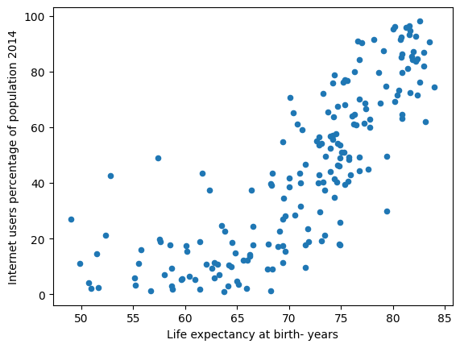

```python
wd.plot(kind='scatter', x='Life expectancy at birth- years', y='Internet users percentage of population 2014')
```

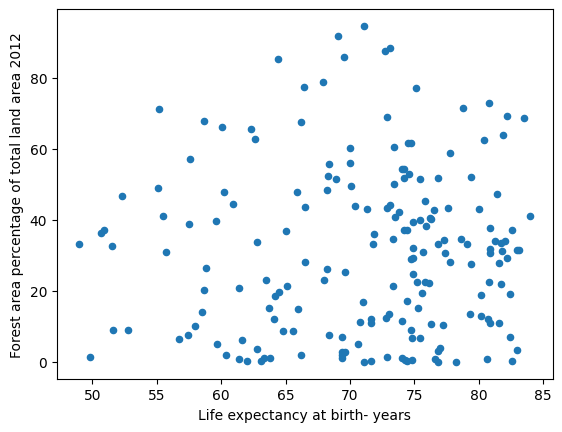

```python
wd.plot(kind='scatter', x='Life expectancy at birth- years', y= 'Forest area percentage of total land area 2012')
```

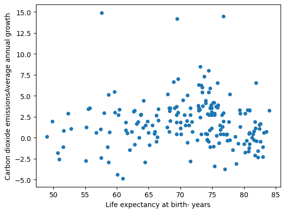

```python
wd.plot(kind='scatter', x='Life expectancy at birth- years', y= 'Carbon dioxide emissionsAverage annual growth')
```

## Seaborn library

statistical data visualization

pdf : probability density function 확률 밀도 함수

- 확률분포의 합은 1
- 어떤 조건에 해당할 확률은 넓이
- 어느 한 사건이 발생할 가능성은 0

kde : kernel density estimation 커널 밀도 추정

```python
import seaborn as sns
```

```python
bd = pd.read_csv('body.csv')
bd
```

|  | Number | Height | Weight |
| --- | --- | --- | --- |
| 0 | 1 | 176.0 | 85.2 |
| 1 | 2 | 175.3 | 67.7 |
| 2 | 3 | 168.6 | 75.2 |
| 3 | 4 | 168.1 | 67.1 |
| 4 | 5 | 175.3 | 63.0 |
| ... | ... | ... | ... |
| 995 | 996 | 171.8 | 68.2 |
| 996 | 997 | 171.5 | 75.6 |
| 997 | 998 | 177.9 | 66.5 |
| 998 | 999 | 174.4 | 72.0 |
| 999 | 1000 | 173.5 | 77.4 |

1000 rows × 3 columns

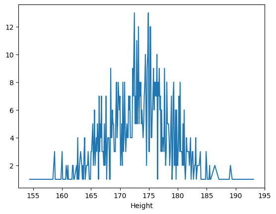

```python
bd['Height'].value_counts().sort_index().plot()
```

이런 실측치를 kde 해서 확률분포로 만들어낸다

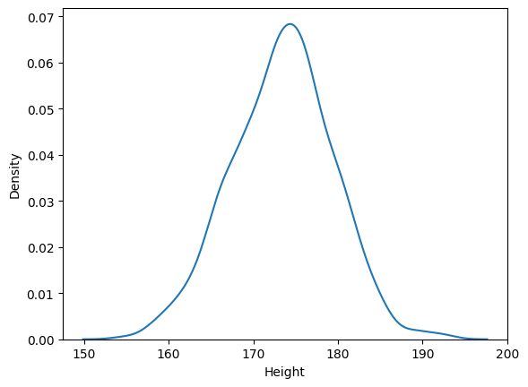

```python
sns.kdeplot(bd['Height'])
```

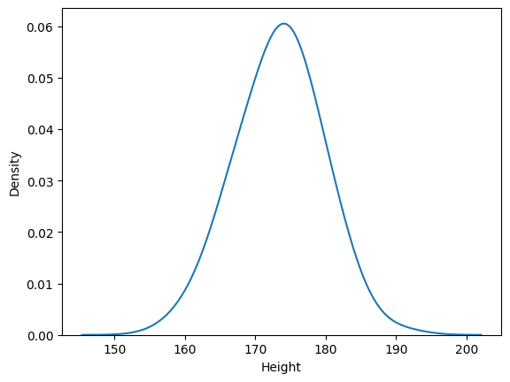

```python
sns.kdeplot(bd['Height'], bw = 0.5)
```

```python
sub = pd.read_csv('subway.csv')
sub
```

|  | line | station | in | out |
| --- | --- | --- | --- | --- |
| 0 | 중앙선 | 지평 | 37 | 28 |
| 1 | 중앙선 | 용문 | 2064 | 2103 |
| 2 | 중앙선 | 원덕 | 375 | 357 |
| 3 | 중앙선 | 양평 | 4338 | 4378 |
| 4 | 중앙선 | 오빈 | 321 | 321 |
| ... | ... | ... | ... | ... |
| 586 | 1호선 | 종로5가 | 31245 | 30678 |
| 587 | 1호선 | 종로3가 | 38099 | 36928 |
| 588 | 1호선 | 종각 | 52310 | 50088 |
| 589 | 1호선 | 시청 | 29150 | 29043 |
| 590 | 1호선 | 서울역 | 58391 | 54356 |

591 rows × 4 columns

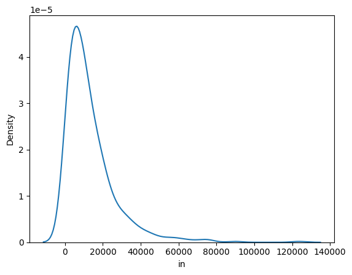

```python
sns.kdeplot(sub['in'])
```

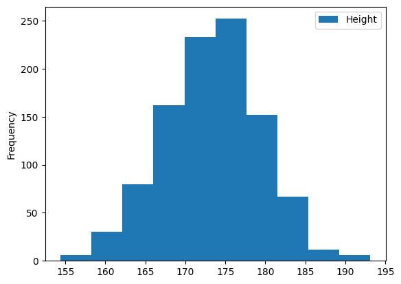

```python
bd.plot(kind='hist', y='Height')
```

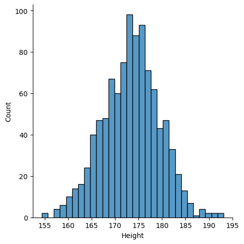

```python
sns.displot(bd['Height'], bins = 30)
```

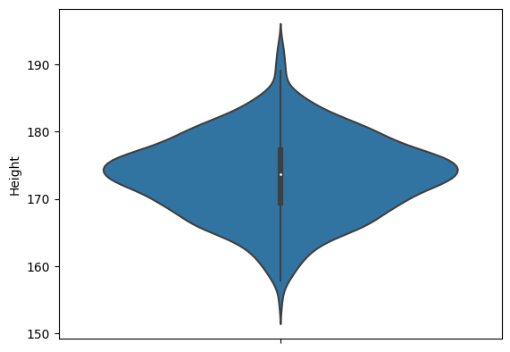

```python
sns.violinplot(y=bd['Height'])
```

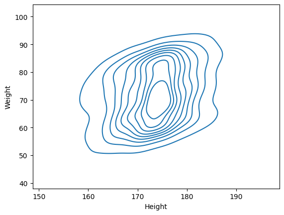

```python
sns.kdeplot(x = bd['Height'], y = bd['Weight'])
```

```python
sal = pd.read_csv('salaries.csv')
sal
```

|  | rank | discipline | yrs.since.phd | yrs.service | sex | salary |
| --- | --- | --- | --- | --- | --- | --- |
| 0 | Prof | B | 56 | 49 | Male | 186960 |
| 1 | Prof | A | 12 | 6 | Male | 93000 |
| 2 | Prof | A | 23 | 20 | Male | 110515 |
| 3 | Prof | A | 40 | 31 | Male | 131205 |
| 4 | Prof | B | 20 | 18 | Male | 104800 |
| ... | ... | ... | ... | ... | ... | ... |
| 73 | Prof | B | 18 | 10 | Female | 105450 |
| 74 | AssocProf | B | 19 | 6 | Female | 104542 |
| 75 | Prof | B | 17 | 17 | Female | 124312 |
| 76 | Prof | A | 28 | 14 | Female | 109954 |
| 77 | Prof | A | 23 | 15 | Female | 109646 |

78 rows × 6 columns

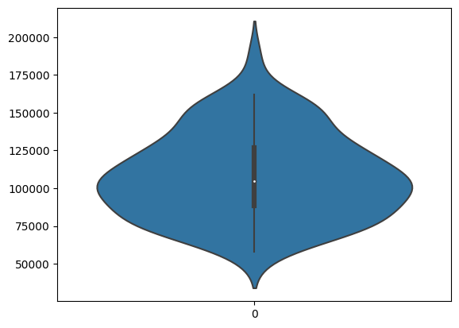

```python
sns.violinplot(sal['salary'])
```

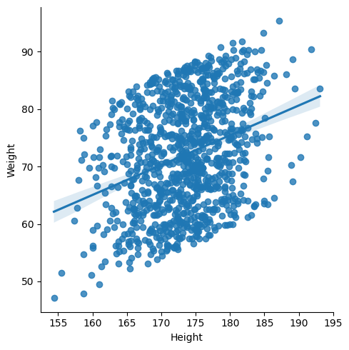

```python
sns.lmplot(data=bd, x='Height', y='Weight')
```

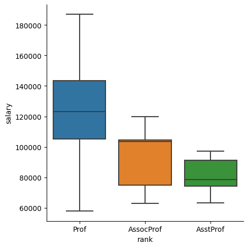

```python
sns.catplot(data = sal, x = 'rank', y = 'salary', kind = 'box')
```

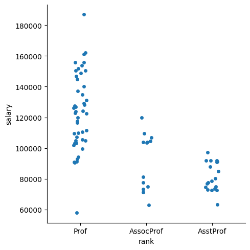

```python
sns.catplot(data = sal, x = 'rank', y = 'salary', kind = 'strip')
```

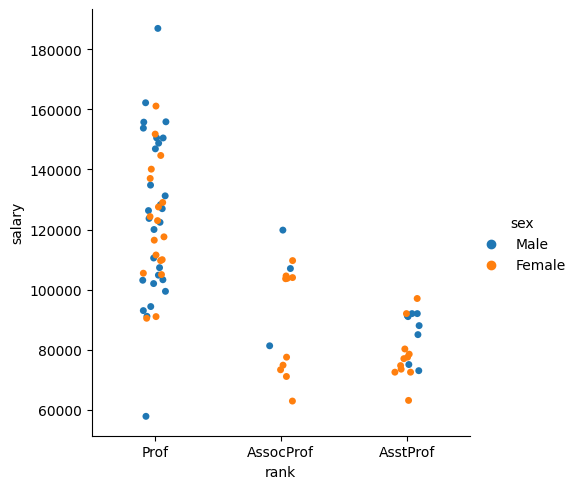

```python
sns.catplot(data = sal, x = 'rank', y = 'salary', kind = 'strip', hue= 'sex')
```

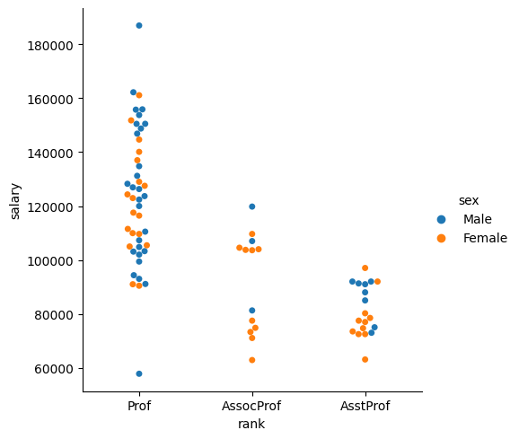

```python
sns.catplot(data = sal, x = 'rank', y = 'salary', kind = 'swarm', hue= 'sex')
```

```python
ins = pd.read_csv('insurance.csv')
ins
```

|  | age | sex | bmi | children | smoker | region | charges |
| --- | --- | --- | --- | --- | --- | --- | --- |
| 0 | 19 | female | 27.900 | 0 | yes | southwest | 16884.92400 |
| 1 | 18 | male | 33.770 | 1 | no | southeast | 1725.55230 |
| 2 | 28 | male | 33.000 | 3 | no | southeast | 4449.46200 |
| 3 | 33 | male | 22.705 | 0 | no | northwest | 21984.47061 |
| 4 | 32 | male | 28.880 | 0 | no | northwest | 3866.85520 |
| ... | ... | ... | ... | ... | ... | ... | ... |
| 1333 | 50 | male | 30.970 | 3 | no | northwest | 10600.54830 |
| 1334 | 18 | female | 31.920 | 0 | no | northeast | 2205.98080 |
| 1335 | 18 | female | 36.850 | 0 | no | southeast | 1629.83350 |
| 1336 | 21 | female | 25.800 | 0 | no | southwest | 2007.94500 |
| 1337 | 61 | female | 29.070 | 0 | yes | northwest | 29141.36030 |

1338 rows × 7 columns

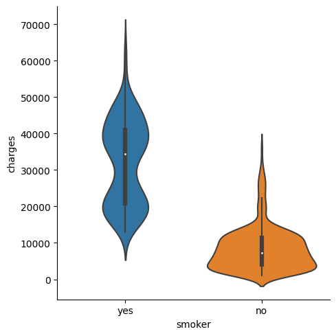

```python
sns.catplot(data = ins, x = 'smoker', y = 'charges', kind = 'violin')
```

```python
lt = [44, 42, 43, 28, 46, 33, 42, 37, 29]
lt.sort()
lt[int((len(lt)+1)/2)]
```

```
42
```

```python
lt = [33, 45, 98, 38, 21, 49, 51, 58, 82, 75]
lt.sort()
lt
```

```
[21, 33, 38, 45, 49, 51, 58, 75, 82, 98]
```

pearson correlation coefficient

## EDA exploratory data analysis

- 각 행, 렬은 무엇을 뜻하는가?
- 각 행, 렬의 값은 어떤 분포를 가지는가?
- 행, 렬들의 조합은 어떤 연관성을 갖는가?

```python
oc = pd.read_csv('occupations.csv')
oc
```

|  | user_id | age | gender | occupation | zip_code |
| --- | --- | --- | --- | --- | --- |
| 0 | 1 | 24 | M | technician | 85711 |
| 1 | 2 | 53 | F | other | 94043 |
| 2 | 3 | 23 | M | writer | 32067 |
| 3 | 4 | 24 | M | technician | 43537 |
| 4 | 5 | 33 | F | other | 15213 |
| ... | ... | ... | ... | ... | ... |
| 938 | 939 | 26 | F | student | 33319 |
| 939 | 940 | 32 | M | administrator | 02215 |
| 940 | 941 | 20 | M | student | 97229 |
| 941 | 942 | 48 | F | librarian | 78209 |
| 942 | 943 | 22 | M | student | 77841 |

943 rows × 5 columns

```python
oc.loc[oc['gender'] == 'F', 'occupation'].value_counts()
```

```
occupation
student          60
other            36
administrator    36
librarian        29
educator         26
writer           19
artist           13
healthcare       11
marketing        10
homemaker         6
programmer        6
none              4
executive         3
scientist         3
salesman          3
engineer          2
lawyer            2
entertainment     2
retired           1
technician        1
Name: count, dtype: int64
```

```python
oc.loc[oc['gender'] == 'M', 'occupation'].value_counts()
```

```
occupation
student          136
other             69
educator          69
engineer          65
programmer        60
administrator     43
executive         29
scientist         28
technician        26
writer            26
librarian         22
entertainment     16
marketing         16
artist            15
retired           13
lawyer            10
salesman           9
doctor             7
none               5
healthcare         5
homemaker          1
Name: count, dtype: int64
```

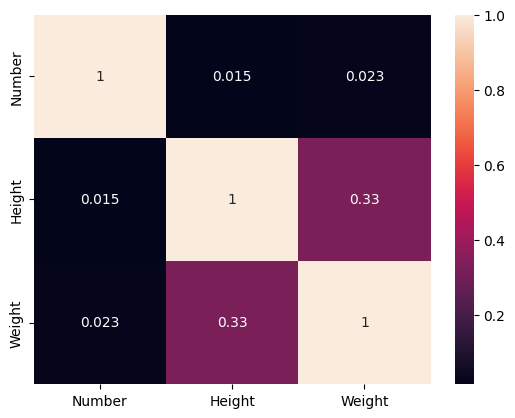

```python
sns.heatmap(bd.corr(), annot= True)
```

```python
ys = pd.read_csv('young_survey.csv')
ys
```

|  | Music | Slow songs or fast songs | Dance | Folk | Country | Classical music | Musical | Pop | Rock | Metal or Hardrock | ... | Spending on looks | Spending on gadgets | Spending on healthy eating | Age | Height | Weight | Number of siblings | Gender | Handedness | Education |
| --- | --- | --- | --- | --- | --- | --- | --- | --- | --- | --- | --- | --- | --- | --- | --- | --- | --- | --- | --- | --- | --- |
| 0 | 5.0 | 3.0 | 2.0 | 1.0 | 2.0 | 2.0 | 1.0 | 5.0 | 5.0 | 1.0 | ... | 3.0 | 1 | 3.0 | 20.0 | 163.0 | 48.0 | 1.0 | female | right | bachelor's degree |
| 1 | 4.0 | 4.0 | 2.0 | 1.0 | 1.0 | 1.0 | 2.0 | 3.0 | 5.0 | 4.0 | ... | 2.0 | 5 | 2.0 | 19.0 | 163.0 | 58.0 | 2.0 | female | right | bachelor's degree |
| 2 | 5.0 | 5.0 | 2.0 | 2.0 | 3.0 | 4.0 | 5.0 | 3.0 | 5.0 | 3.0 | ... | 3.0 | 4 | 2.0 | 20.0 | 176.0 | 67.0 | 2.0 | female | right | high school |
| 3 | 5.0 | 3.0 | 2.0 | 1.0 | 1.0 | 1.0 | 1.0 | 2.0 | 2.0 | 1.0 | ... | 4.0 | 4 | 1.0 | 22.0 | 172.0 | 59.0 | 1.0 | female | right | bachelor's degree |
| 4 | 5.0 | 3.0 | 4.0 | 3.0 | 2.0 | 4.0 | 3.0 | 5.0 | 3.0 | 1.0 | ... | 3.0 | 2 | 4.0 | 20.0 | 170.0 | 59.0 | 1.0 | female | right | high school |
| ... | ... | ... | ... | ... | ... | ... | ... | ... | ... | ... | ... | ... | ... | ... | ... | ... | ... | ... | ... | ... | ... |
| 992 | 5.0 | 2.0 | 5.0 | 2.0 | 2.0 | 5.0 | 4.0 | 4.0 | 4.0 | 3.0 | ... | 4.0 | 3 | 4.0 | 20.0 | 164.0 | 57.0 | 1.0 | female | right | high school |
| 993 | 4.0 | 4.0 | 5.0 | 1.0 | 3.0 | 4.0 | 1.0 | 4.0 | 1.0 | 1.0 | ... | 1.0 | 5 | 3.0 | 27.0 | 183.0 | 80.0 | 5.0 | male | left | master's degree |
| 994 | 4.0 | 3.0 | 1.0 | 1.0 | 2.0 | 2.0 | 2.0 | 3.0 | 4.0 | 1.0 | ... | 2.0 | 2 | 5.0 | 18.0 | 173.0 | 75.0 | 0.0 | female | right | high school |
| 995 | 5.0 | 3.0 | 3.0 | 3.0 | 1.0 | 3.0 | 1.0 | 3.0 | 4.0 | 1.0 | ... | 3.0 | 3 | 3.0 | 25.0 | 173.0 | 58.0 | 1.0 | female | right | bachelor's degree |
| 996 | 5.0 | 5.0 | 4.0 | 3.0 | 2.0 | 3.0 | 3.0 | 4.0 | 1.0 | 1.0 | ... | 1.0 | 1 | 5.0 | 21.0 | 185.0 | 72.0 | 1.0 | male | right | high school |

997 rows × 147 columns

```python
ys.corr()
```

[output not shown]

```python
yv = pd.read_csv('young_surv.csv')
yv
```

|  | Music | Slow songs or fast songs | Dance | Folk | Country | Classical music | Musical | Pop | Rock | Metal or Hardrock | ... | Spending on looks | Spending on gadgets | Spending on healthy eating | Age | Height | Weight | Number of siblings | Gender | Handedness | Education |
| --- | --- | --- | --- | --- | --- | --- | --- | --- | --- | --- | --- | --- | --- | --- | --- | --- | --- | --- | --- | --- | --- |
| 0 | 5.0 | 3.0 | 2.0 | 1.0 | 2.0 | 2.0 | 1.0 | 5.0 | 5.0 | 1.0 | ... | 3.0 | 1 | 3.0 | 20.0 | 163.0 | 48.0 | 1.0 | female | right | bachelor's degree |
| 1 | 4.0 | 4.0 | 2.0 | 1.0 | 1.0 | 1.0 | 2.0 | 3.0 | 5.0 | 4.0 | ... | 2.0 | 5 | 2.0 | 19.0 | 163.0 | 58.0 | 2.0 | female | right | bachelor's degree |
| 2 | 5.0 | 5.0 | 2.0 | 2.0 | 3.0 | 4.0 | 5.0 | 3.0 | 5.0 | 3.0 | ... | 3.0 | 4 | 2.0 | 20.0 | 176.0 | 67.0 | 2.0 | female | right | high school |
| 3 | 5.0 | 3.0 | 2.0 | 1.0 | 1.0 | 1.0 | 1.0 | 2.0 | 2.0 | 1.0 | ... | 4.0 | 4 | 1.0 | 22.0 | 172.0 | 59.0 | 1.0 | female | right | bachelor's degree |
| 4 | 5.0 | 3.0 | 4.0 | 3.0 | 2.0 | 4.0 | 3.0 | 5.0 | 3.0 | 1.0 | ... | 3.0 | 2 | 4.0 | 20.0 | 170.0 | 59.0 | 1.0 | female | right | high school |
| ... | ... | ... | ... | ... | ... | ... | ... | ... | ... | ... | ... | ... | ... | ... | ... | ... | ... | ... | ... | ... | ... |
| 992 | 5.0 | 2.0 | 5.0 | 2.0 | 2.0 | 5.0 | 4.0 | 4.0 | 4.0 | 3.0 | ... | 4.0 | 3 | 4.0 | 20.0 | 164.0 | 57.0 | 1.0 | female | right | high school |
| 993 | 4.0 | 4.0 | 5.0 | 1.0 | 3.0 | 4.0 | 1.0 | 4.0 | 1.0 | 1.0 | ... | 1.0 | 5 | 3.0 | 27.0 | 183.0 | 80.0 | 5.0 | male | left | master's degree |
| 994 | 4.0 | 3.0 | 1.0 | 1.0 | 2.0 | 2.0 | 2.0 | 3.0 | 4.0 | 1.0 | ... | 2.0 | 2 | 5.0 | 18.0 | 173.0 | 75.0 | 0.0 | female | right | high school |
| 995 | 5.0 | 3.0 | 3.0 | 3.0 | 1.0 | 3.0 | 1.0 | 3.0 | 4.0 | 1.0 | ... | 3.0 | 3 | 3.0 | 25.0 | 173.0 | 58.0 | 1.0 | female | right | bachelor's degree |
| 996 | 5.0 | 5.0 | 4.0 | 3.0 | 2.0 | 3.0 | 3.0 | 4.0 | 1.0 | 1.0 | ... | 1.0 | 1 | 5.0 | 21.0 | 185.0 | 72.0 | 1.0 | male | right | high school |

997 rows × 147 columns

```python
yv[['Branded clothing', 'Spending on looks']].corr()
```

|  | Branded clothing | Spending on looks |
| --- | --- | --- |
| Branded clothing | 1.000000 | 0.418399 |
| Spending on looks | 0.418399 | 1.000000 |

```python
yv[['Musical instruments','Writing']].corr()
```

|  | Musical instruments | Writing |
| --- | --- | --- |
| Musical instruments | 1.000000 | 0.343816 |
| Writing | 0.343816 | 1.000000 |

```python
yv[['New environment','Writing notes']].corr()
```

|  | New environment | Writing notes |
| --- | --- | --- |
| New environment | 1.000000 | -0.079397 |
| Writing notes | -0.079397 | 1.000000 |

```python
yvs = yv.loc[:, 'Music':'Metal or Hardrock']
```

```python
corr = yvs.corr()
corr
```

|  | Music | Slow songs or fast songs | Dance | Folk | Country | Classical music | Musical | Pop | Rock | Metal or Hardrock |
| --- | --- | --- | --- | --- | --- | --- | --- | --- | --- | --- |
| Music | 1.000000 | 0.075426 | 0.066719 | 0.027648 | -0.014272 | 0.055648 | 0.056730 | 0.059967 | 0.149958 | 0.016043 |
| Slow songs or fast songs | 0.075426 | 1.000000 | 0.188217 | -0.062023 | -0.072138 | -0.159021 | -0.078479 | 0.054375 | -0.018347 | 0.050913 |
| Dance | 0.066719 | 0.188217 | 1.000000 | 0.065863 | 0.055106 | -0.093125 | 0.067430 | 0.424794 | -0.147867 | -0.241477 |
| Folk | 0.027648 | -0.062023 | 0.065863 | 1.000000 | 0.391850 | 0.366988 | 0.263987 | 0.023641 | 0.056471 | 0.062454 |
| Country | -0.014272 | -0.072138 | 0.055106 | 0.391850 | 1.000000 | 0.257474 | 0.202831 | 0.000716 | 0.129917 | 0.115289 |
| Classical music | 0.055648 | -0.159021 | -0.093125 | 0.366988 | 0.257474 | 1.000000 | 0.351101 | -0.048159 | 0.217929 | 0.176309 |
| Musical | 0.056730 | -0.078479 | 0.067430 | 0.263987 | 0.202831 | 0.351101 | 1.000000 | 0.223045 | 0.094484 | -0.029776 |
| Pop | 0.059967 | 0.054375 | 0.424794 | 0.023641 | 0.000716 | -0.048159 | 0.223045 | 1.000000 | -0.029376 | -0.289975 |
| Rock | 0.149958 | -0.018347 | -0.147867 | 0.056471 | 0.129917 | 0.217929 | 0.094484 | -0.029376 | 1.000000 | 0.527272 |
| Metal or Hardrock | 0.016043 | 0.050913 | -0.241477 | 0.062454 | 0.115289 | 0.176309 | -0.029776 | -0.289975 | 0.527272 | 1.000000 |

```python
corr['Pop'].sort_values(ascending=False)
```

```
Pop                         1.000000
Dance                       0.424794
Musical                     0.223045
Music                       0.059967
Slow songs or fast songs    0.054375
Folk                        0.023641
Country                     0.000716
Rock                       -0.029376
Classical music            -0.048159
Metal or Hardrock          -0.289975
Name: Pop, dtype: float64
```

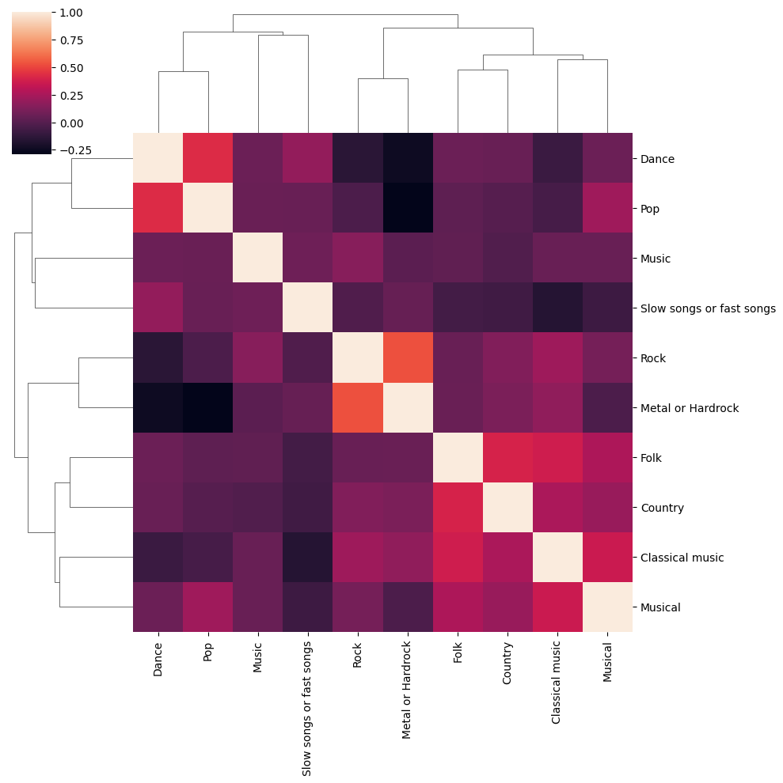

```python
sns.clustermap(corr)
```

```python
mov = pd.read_csv('survey.csv')
mov = mov.loc[:,'Horror':'Action']
```

```python
mcorr = mov.corr()
mcorr
```

|  | Horror | Thriller | Comedy | Romantic | Sci-fi | War | Fantasy/Fairy tales | Animated | Documentary | Western | Action |
| --- | --- | --- | --- | --- | --- | --- | --- | --- | --- | --- | --- |
| Horror | 1.000000 | 0.503069 | 0.098243 | -0.128117 | 0.165834 | 0.136508 | -0.087150 | 0.004865 | -0.063749 | 0.078845 | 0.129958 |
| Thriller | 0.503069 | 1.000000 | -0.008975 | -0.164751 | 0.230838 | 0.220754 | -0.090075 | -0.025239 | 0.046558 | 0.124719 | 0.278214 |
| Comedy | 0.098243 | -0.008975 | 1.000000 | 0.286236 | 0.040425 | -0.077274 | 0.211025 | 0.180246 | -0.007444 | -0.033091 | 0.121256 |
| Romantic | -0.128117 | -0.164751 | 0.286236 | 1.000000 | -0.097219 | -0.193751 | 0.349432 | 0.239951 | -0.083895 | -0.126574 | -0.181823 |
| Sci-fi | 0.165834 | 0.230838 | 0.040425 | -0.097219 | 1.000000 | 0.274634 | -0.009158 | 0.068642 | 0.141714 | 0.276898 | 0.363429 |
| War | 0.136508 | 0.220754 | -0.077274 | -0.193751 | 0.274634 | 1.000000 | -0.072474 | -0.026996 | 0.235355 | 0.396669 | 0.299257 |
| Fantasy/Fairy tales | -0.087150 | -0.090075 | 0.211025 | 0.349432 | -0.009158 | -0.072474 | 1.000000 | 0.679270 | 0.140227 | -0.023267 | -0.051591 |
| Animated | 0.004865 | -0.025239 | 0.180246 | 0.239951 | 0.068642 | -0.026996 | 0.679270 | 1.000000 | 0.148375 | -0.003069 | 0.019379 |
| Documentary | -0.063749 | 0.046558 | -0.007444 | -0.083895 | 0.141714 | 0.235355 | 0.140227 | 0.148375 | 1.000000 | 0.263859 | 0.131062 |
| Western | 0.078845 | 0.124719 | -0.033091 | -0.126574 | 0.276898 | 0.396669 | -0.023267 | -0.003069 | 0.263859 | 1.000000 | 0.320005 |
| Action | 0.129958 | 0.278214 | 0.121256 | -0.181823 | 0.363429 | 0.299257 | -0.051591 | 0.019379 | 0.131062 | 0.320005 | 1.000000 |

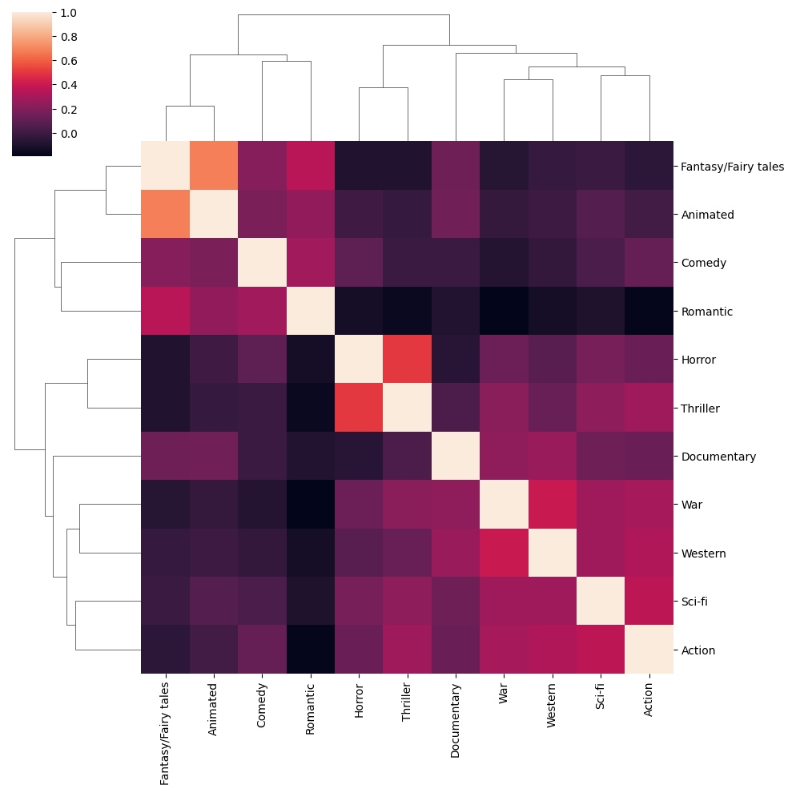

```python
sns.clustermap(mcorr)
```

```python
ti = pd.read_csv('titanic.csv', index_col=0)
ti
```

| PassengerId | Survived | Pclass | Name | Sex | Age | SibSp | Parch | Ticket | Fare | Cabin | Embarked |
| --- | --- | --- | --- | --- | --- | --- | --- | --- | --- | --- | --- |
| 1 | 0 | 3 | Braund, Mr. Owen Harris | male | 22.0 | 1 | 0 | A/5 21171 | 7.2500 | NaN | S |
| 2 | 1 | 1 | Cumings, Mrs. John Bradley (Florence Briggs Th... | female | 38.0 | 1 | 0 | PC 17599 | 71.2833 | C85 | C |
| 3 | 1 | 3 | Heikkinen, Miss. Laina | female | 26.0 | 0 | 0 | STON/O2. 3101282 | 7.9250 | NaN | S |
| 4 | 1 | 1 | Futrelle, Mrs. Jacques Heath (Lily May Peel) | female | 35.0 | 1 | 0 | 113803 | 53.1000 | C123 | S |
| 5 | 0 | 3 | Allen, Mr. William Henry | male | 35.0 | 0 | 0 | 373450 | 8.0500 | NaN | S |
| ... | ... | ... | ... | ... | ... | ... | ... | ... | ... | ... | ... |
| 887 | 0 | 2 | Montvila, Rev. Juozas | male | 27.0 | 0 | 0 | 211536 | 13.0000 | NaN | S |
| 888 | 1 | 1 | Graham, Miss. Margaret Edith | female | 19.0 | 0 | 0 | 112053 | 30.0000 | B42 | S |
| 889 | 0 | 3 | Johnston, Miss. Catherine Helen "Carrie" | female | NaN | 1 | 2 | W./C. 6607 | 23.4500 | NaN | S |
| 890 | 1 | 1 | Behr, Mr. Karl Howell | male | 26.0 | 0 | 0 | 111369 | 30.0000 | C148 | C |
| 891 | 0 | 3 | Dooley, Mr. Patrick | male | 32.0 | 0 | 0 | 370376 | 7.7500 | NaN | Q |

891 rows × 11 columns

```python
ti = ti.drop(['Name', 'Ticket', 'Cabin', "Embarked", 'Sex'], axis='columns')
```

```python
ti['Survived'].value_counts()
```

```
Survived
0    549
1    342
Name: count, dtype: int64
```

```python
ti.corr()
```

|  | Survived | Pclass | Age | SibSp | Parch | Fare |
| --- | --- | --- | --- | --- | --- | --- |
| Survived | 1.000000 | -0.338481 | -0.077221 | -0.035322 | 0.081629 | 0.257307 |
| Pclass | -0.338481 | 1.000000 | -0.369226 | 0.083081 | 0.018443 | -0.549500 |
| Age | -0.077221 | -0.369226 | 1.000000 | -0.308247 | -0.189119 | 0.096067 |
| SibSp | -0.035322 | 0.083081 | -0.308247 | 1.000000 | 0.414838 | 0.159651 |
| Parch | 0.081629 | 0.018443 | -0.189119 | 0.414838 | 1.000000 | 0.216225 |
| Fare | 0.257307 | -0.549500 | 0.096067 | 0.159651 | 0.216225 | 1.000000 |

```python
ti['Pclass'].value_counts()
```

```
Pclass
3    491
1    216
2    184
Name: count, dtype: int64
```

```python
ti.loc[ti['Survived'] == 1, 'Pclass'].value_counts()
```

```
Pclass
1    136
3    119
2     87
Name: count, dtype: int64
```

```python
ti[['Survived', 'Age']].corr()
```

|  | Survived | Age |
| --- | --- | --- |
| Survived | 1.000000 | -0.077221 |
| Age | -0.077221 | 1.000000 |

```python
ti.loc[ti['Sex']== 'male', 'Sex'] = 1
ti.loc[ti['Sex']== 'female', 'Sex'] = 0
```

```python
ti[['Survived', 'Sex']].corr()
```

[output not shown]

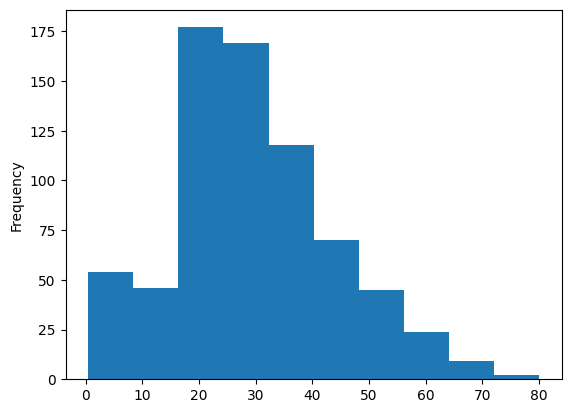

```python
ti['Age'].plot(kind='hist')
```

```python
ti[['Age','Fare']].sort_values(by = 'Fare')
```

| PassengerId | Age | Fare |
| --- | --- | --- |
| 272 | 25.0 | 0.0000 |
| 598 | 49.0 | 0.0000 |
| 303 | 19.0 | 0.0000 |
| 634 | NaN | 0.0000 |
| 278 | NaN | 0.0000 |
| ... | ... | ... |
| 439 | 64.0 | 263.0000 |
| 342 | 24.0 | 263.0000 |
| 738 | 35.0 | 512.3292 |
| 259 | 35.0 | 512.3292 |
| 680 | 36.0 | 512.3292 |

891 rows × 2 columns

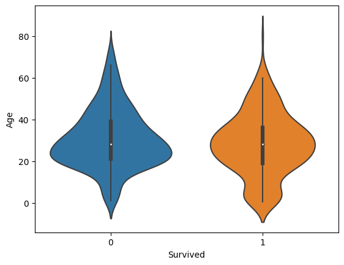

```python
sns.violinplot(data=ti, x="Survived", y="Age")
```

```python
df = pd.read_csv('broadcast.csv', index_col=0)
```

```python
df['total'] = df.loc[:,:].sum(axis='columns')
df['major'] = df.loc[:, 'KBS':'SBS'].sum(axis='columns')
df['jp'] = df.loc[:, 'TV CHOSUN':'MBN'].sum(axis='columns')

df
```

|  | KBS | MBC | SBS | TV CHOSUN | JTBC | Channel A | MBN | total | major | jp |
| --- | --- | --- | --- | --- | --- | --- | --- | --- | --- | --- |
| 2011 | 35.951 | 18.374 | 11.173 | 9.102 | 7.380 | 3.771 | 2.809 | 88.560 | 65.498 | 23.062 |
| 2012 | 36.163 | 16.022 | 11.408 | 8.785 | 7.878 | 5.874 | 3.310 | 89.440 | 63.593 | 25.847 |
| 2013 | 31.989 | 16.778 | 9.673 | 9.026 | 7.810 | 5.350 | 3.825 | 84.451 | 58.440 | 26.011 |
| 2014 | 31.210 | 15.663 | 9.108 | 9.440 | 7.490 | 5.776 | 4.572 | 83.259 | 55.981 | 27.278 |
| 2015 | 27.777 | 16.573 | 9.099 | 9.940 | 7.267 | 6.678 | 5.520 | 82.854 | 53.449 | 29.405 |
| 2016 | 27.583 | 14.982 | 8.669 | 9.829 | 7.727 | 6.624 | 5.477 | 80.891 | 51.234 | 29.657 |
| 2017 | 26.890 | 12.465 | 8.661 | 8.886 | 9.453 | 6.056 | 5.215 | 77.626 | 48.016 | 29.610 |

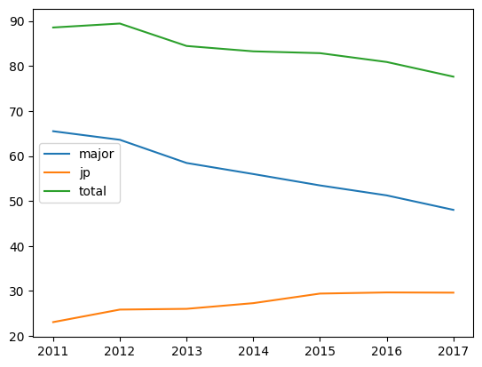

```python
df.plot(y=['major', 'jp', 'total'])
```

## 문자열

1. 칼럼 안에 값이 특정 문자열을 갖고 있을 때
- df['col'].str.contains()
- df['col'].str.startswith()

```python
ms = pd.read_csv('museum_1.csv')
ms
```

|  | 시설명 | 어른관람료 | 운영기관전화번호 |
| --- | --- | --- | --- |
| 0 | 필암서원 유물전시관 | 500 | 061-390-7224 |
| 1 | 원주역사박물관 | 0 | 033-737-4371 |
| 2 | 뮤지엄산미술관 | 15000 | 033-730-9000 |
| 3 | 오랜미래신화미술관 | 0 | 033-746-5256 |
| 4 | 연세대학교 원주박물관 | 0 | 033-760-2731 |
| ... | ... | ... | ... |
| 895 | 함양박물관 | 0 | 055-960-5532 |
| 896 | 박물관수 | 5000 | 053-744-5500 |
| 897 | 대구은행금융박물관 | 0 | 053-740-2061 |
| 898 | 국립대구박물관 | 0 | 053-768-6051 |
| 899 | 증평민속체험박물관 | 0 | 043-835-4161 |

900 rows × 3 columns

```python
univ = ms['시설명'].str.contains('대학')
ms['분류'] = '일반'
ms.loc[univ, '분류'] = '대학'
ms
```

|  | 시설명 | 어른관람료 | 운영기관전화번호 | 분류 |
| --- | --- | --- | --- | --- |
| 0 | 필암서원 유물전시관 | 500 | 061-390-7224 | 일반 |
| 1 | 원주역사박물관 | 0 | 033-737-4371 | 일반 |
| 2 | 뮤지엄산미술관 | 15000 | 033-730-9000 | 일반 |
| 3 | 오랜미래신화미술관 | 0 | 033-746-5256 | 일반 |
| 4 | 연세대학교 원주박물관 | 0 | 033-760-2731 | 대학 |
| ... | ... | ... | ... | ... |
| 895 | 함양박물관 | 0 | 055-960-5532 | 일반 |
| 896 | 박물관수 | 5000 | 053-744-5500 | 일반 |
| 897 | 대구은행금융박물관 | 0 | 053-740-2061 | 일반 |
| 898 | 국립대구박물관 | 0 | 053-768-6051 | 일반 |
| 899 | 증평민속체험박물관 | 0 | 043-835-4161 | 일반 |

900 rows × 4 columns

2. 칼럼 안의 문자열을 쪼개고 싶을 때
- df['col'].str.split(n=x, expand=True)
- 학습자료는 pat을 설명하지 않았으나 공식 문서 참조해서 확인. 이렇게 하는 게 공부긴 하다
- expand를 true로 해서 데이터프레임으로 만들어야 0번 칼럼을 통째로 떠올 수 있구나
- 만약 시리즈로 뗐으면 리스트라서 0번 인덱스가 가져와진다

```python
n = ms['운영기관전화번호'].str.split(n=1, pat='-', expand=True)
ms['지역번호'] = n[0]
ms
```

|  | 시설명 | 어른관람료 | 운영기관전화번호 | 분류 | 지역번호 |
| --- | --- | --- | --- | --- | --- |
| 0 | 필암서원 유물전시관 | 500 | 061-390-7224 | 일반 | 061 |
| 1 | 원주역사박물관 | 0 | 033-737-4371 | 일반 | 033 |
| 2 | 뮤지엄산미술관 | 15000 | 033-730-9000 | 일반 | 033 |
| 3 | 오랜미래신화미술관 | 0 | 033-746-5256 | 일반 | 033 |
| 4 | 연세대학교 원주박물관 | 0 | 033-760-2731 | 대학 | 033 |
| ... | ... | ... | ... | ... | ... |
| 895 | 함양박물관 | 0 | 055-960-5532 | 일반 | 055 |
| 896 | 박물관수 | 5000 | 053-744-5500 | 일반 | 053 |
| 897 | 대구은행금융박물관 | 0 | 053-740-2061 | 일반 | 053 |
| 898 | 국립대구박물관 | 0 | 053-768-6051 | 일반 | 053 |
| 899 | 증평민속체험박물관 | 0 | 043-835-4161 | 일반 | 043 |

900 rows × 5 columns

3. 칼럼 안의 문자열을 치환 할 때
- df['col'].map(dict)
- dict는 dict = {'a' : 'b'} 바꾸려는 문자와 치환값이 있어야 한다

```python
loc = {'02':'서울시',
       '031': '경기도',
       '032': '경기도',
       '033': '강원도',
       '041': '충청도',
       '042': '충청도',
       '043': '충청도',
       '044': '충청도',
       '051': '부산시',
       '052': '경상도',
       '053': '경상도',
       '054': '경상도',
       '055': '경상도',
       '061': '전라도',
       '062': '전라도',
       '063': '전라도',
       '064': '제주도',
       '1577': '기타',
       '070':'기타'
       }
```

```python
ms = ms.astype({'지역번호':'str'})
ms.dtypes
```

```
시설명         object
어른관람료        int64
운영기관전화번호    object
분류          object
지역번호        object
dtype: object
```

```python
# 칼럼을 추가하고
ms['지역명'] = ms['지역번호'].map(loc)
# 기존 칼럼을 없앤다
ms.drop('지역번호', axis='columns', inplace=True)
ms
```

|  | 시설명 | 어른관람료 | 운영기관전화번호 | 분류 | 지역명 |
| --- | --- | --- | --- | --- | --- |
| 0 | 필암서원 유물전시관 | 500 | 061-390-7224 | 일반 | 전라도 |
| 1 | 원주역사박물관 | 0 | 033-737-4371 | 일반 | 강원도 |
| 2 | 뮤지엄산미술관 | 15000 | 033-730-9000 | 일반 | 강원도 |
| 3 | 오랜미래신화미술관 | 0 | 033-746-5256 | 일반 | 강원도 |
| 4 | 연세대학교 원주박물관 | 0 | 033-760-2731 | 대학 | 강원도 |
| ... | ... | ... | ... | ... | ... |
| 895 | 함양박물관 | 0 | 055-960-5532 | 일반 | 경상도 |
| 896 | 박물관수 | 5000 | 053-744-5500 | 일반 | 경상도 |
| 897 | 대구은행금융박물관 | 0 | 053-740-2061 | 일반 | 경상도 |
| 898 | 국립대구박물관 | 0 | 053-768-6051 | 일반 | 경상도 |
| 899 | 증평민속체험박물관 | 0 | 043-835-4161 | 일반 | 충청도 |

900 rows × 5 columns

```python
# 해설 답안은 칼럼 내용을 바꾸고 칼럼 이름을 바꿨다
# ms["지역번호"] = ms["지역번호"].map(loc)
# ms.rename(columns={"지역번호": "지역명"}, inplace=True)
# ms
```

4. 칼럼을 묶어줄 때
- df.groupby('col')

```python
occ = pd.read_csv('occupations_2.csv')
og = occ[['occupation', 'age']].groupby('occupation')
og
```

```
<pandas.core.groupby.generic.DataFrameGroupBy object at 0x0000022295A828C0>
```

```python
og.count()
```

| occupation | age |
| --- | --- |
| administrator | 79 |
| artist | 28 |
| doctor | 7 |
| educator | 95 |
| engineer | 67 |
| entertainment | 18 |
| executive | 32 |
| healthcare | 16 |
| homemaker | 7 |
| lawyer | 12 |
| librarian | 51 |
| marketing | 26 |
| none | 9 |
| other | 105 |
| programmer | 66 |
| retired | 14 |
| salesman | 12 |
| scientist | 31 |
| student | 196 |
| technician | 27 |
| writer | 45 |

```python
og.mean().sort_values(by='age')
```

| occupation | age |
| --- | --- |
| student | 22.081633 |
| none | 26.555556 |
| entertainment | 29.222222 |
| artist | 31.392857 |
| homemaker | 32.571429 |
| programmer | 33.121212 |
| technician | 33.148148 |
| other | 34.523810 |
| scientist | 35.548387 |
| salesman | 35.666667 |
| writer | 36.311111 |
| engineer | 36.388060 |
| lawyer | 36.750000 |
| marketing | 37.615385 |
| executive | 38.718750 |
| administrator | 38.746835 |
| librarian | 40.000000 |
| healthcare | 41.562500 |
| educator | 42.010526 |
| doctor | 43.571429 |
| retired | 63.071429 |

```python
og2 = occ[['occupation', 'gender']].groupby('occupation')
og2.count()
```

| occupation | gender |
| --- | --- |
| administrator | 79 |
| artist | 28 |
| doctor | 7 |
| educator | 95 |
| engineer | 67 |
| entertainment | 18 |
| executive | 32 |
| healthcare | 16 |
| homemaker | 7 |
| lawyer | 12 |
| librarian | 51 |
| marketing | 26 |
| none | 9 |
| other | 105 |
| programmer | 66 |
| retired | 14 |
| salesman | 12 |
| scientist | 31 |
| student | 196 |
| technician | 27 |
| writer | 45 |

```python
og2.describe()
```

| occupation | gender count | gender unique | gender top | gender freq |
| --- | --- | --- | --- | --- |
| administrator | 79 | 2 | M | 43 |
| artist | 28 | 2 | M | 15 |
| doctor | 7 | 1 | M | 7 |
| educator | 95 | 2 | M | 69 |
| engineer | 67 | 2 | M | 65 |
| entertainment | 18 | 2 | M | 16 |
| executive | 32 | 2 | M | 29 |
| healthcare | 16 | 2 | F | 11 |
| homemaker | 7 | 2 | F | 6 |
| lawyer | 12 | 2 | M | 10 |
| librarian | 51 | 2 | F | 29 |
| marketing | 26 | 2 | M | 16 |
| none | 9 | 2 | M | 5 |
| other | 105 | 2 | M | 69 |
| programmer | 66 | 2 | M | 60 |
| retired | 14 | 2 | M | 13 |
| salesman | 12 | 2 | M | 9 |
| scientist | 31 | 2 | M | 28 |
| student | 196 | 2 | M | 136 |
| technician | 27 | 2 | M | 26 |
| writer | 45 | 2 | M | 26 |

```python
og2[og2['gender'] == 'M']
```

[output not shown]

```python
occ['male'] = 0
occ.loc[occ['gender'] == 'M', 'male'] = 1
occ['female'] = 0
occ.loc[occ['gender'] == 'F', 'female'] = 1
occ['gender'] = occ['female']
occ
```

|  | age | gender | occupation | male | female |
| --- | --- | --- | --- | --- | --- |
| 0 | 24 | 0 | technician | 1 | 0 |
| 1 | 53 | 1 | other | 0 | 1 |
| 2 | 23 | 0 | writer | 1 | 0 |
| 3 | 24 | 0 | technician | 1 | 0 |
| 4 | 33 | 1 | other | 0 | 1 |
| ... | ... | ... | ... | ... | ... |
| 938 | 26 | 1 | student | 0 | 1 |
| 939 | 32 | 0 | administrator | 1 | 0 |
| 940 | 20 | 0 | student | 1 | 0 |
| 941 | 48 | 1 | librarian | 0 | 1 |
| 942 | 22 | 0 | student | 1 | 0 |

943 rows × 5 columns

```python
og3 = occ[['occupation', 'gender']].groupby('occupation')
og3.mean().sort_values(by='gender', ascending=False)
```

| occupation | gender |
| --- | --- |
| homemaker | 0.857143 |
| healthcare | 0.687500 |
| librarian | 0.568627 |
| artist | 0.464286 |
| administrator | 0.455696 |
| none | 0.444444 |
| writer | 0.422222 |
| marketing | 0.384615 |
| other | 0.342857 |
| student | 0.306122 |
| educator | 0.273684 |
| salesman | 0.250000 |
| lawyer | 0.166667 |
| entertainment | 0.111111 |
| scientist | 0.096774 |
| executive | 0.093750 |
| programmer | 0.090909 |
| retired | 0.071429 |
| technician | 0.037037 |
| engineer | 0.029851 |
| doctor | 0.000000 |

5. 데이터 합치기
- 기준으로 하는 칼럼의 값에 대해서
- inner join
  - 교집합 A & B
  - 기준 칼럼 안에 같은 이름을 갖는 값을 기준으로 데이터를 합친다
- left outer join
  - 집합 A
  - 기준 칼럼 안에 같은 이름을 갖는 값과 왼쪽(집합A) 칼럼의 데이터를 합친다
- right outer join
  - 집합 B
  - 기준 칼럼 안에 같은 이름을 갖는 값과 오른쪽(집합B) 칼럼의 데이터를 합친다
- full outer join
  - 합집합 A + B
  - 기준 칼럼 안에 모든 이름의 데이터를 합친다

[figure not shown]

```python
ms3 = pd.read_csv('museum_3.csv')
reg = pd.read_csv('region_number.csv')
msreg = pd.merge(ms3, reg, on='지역번호', how='left')
msreg
```

|  | 시설명 | 어른관람료 | 운영기관전화번호 | 분류 | 지역번호 | 지역명 |
| --- | --- | --- | --- | --- | --- | --- |
| 0 | 필암서원 유물전시관 | 500 | 061-390-7224 | 일반 | 61 | 전라남도 |
| 1 | 원주역사박물관 | 0 | 033-737-4371 | 일반 | 33 | 강원도 |
| 2 | 뮤지엄산미술관 | 15000 | 033-730-9000 | 일반 | 33 | 강원도 |
| 3 | 오랜미래신화미술관 | 0 | 033-746-5256 | 일반 | 33 | 강원도 |
| 4 | 연세대학교 원주박물관 | 0 | 033-760-2731 | 대학 | 33 | 강원도 |
| ... | ... | ... | ... | ... | ... | ... |
| 895 | 함양박물관 | 0 | 055-960-5532 | 일반 | 55 | 경상남도 |
| 896 | 박물관수 | 5000 | 053-744-5500 | 일반 | 53 | 대구광역시 |
| 897 | 대구은행금융박물관 | 0 | 053-740-2061 | 일반 | 53 | 대구광역시 |
| 898 | 국립대구박물관 | 0 | 053-768-6051 | 일반 | 53 | 대구광역시 |
| 899 | 증평민속체험박물관 | 0 | 043-835-4161 | 일반 | 43 | 충청북도 |

900 rows × 6 columns